# Chapter8App7

Adam Prado Data Science 4/14/24

Chapter 8 Applied #7

Downloads libraries for creating trees/forests and the Boston data set.

```r
library(ISLR2)
library(tree)
library(randomForest)
attach(Boston)
View(Boston)
```

Sets the random seed and splits the data set in half to make the training data, and thus the test data set by using [-train]

```r
set.seed(1)
train <- sample(1:nrow(Boston), nrow(Boston)/2)
tree.boston <- tree(medv~., Boston, subset=train)
summary(tree.boston)
```

```
##
## Regression tree:
## tree(formula = medv ~ ., data = Boston, subset = train)
## Variables actually used in tree construction:
## [1] "rm"    "lstat" "crim"  "age"
## Number of terminal nodes:  7
## Residual mean deviance:  10.38 = 2555 / 246
## Distribution of residuals:
##     Min.  1st Qu.   Median     Mean  3rd Qu.     Max.
## -10.1800  -1.7770  -0.1775   0.0000   1.9230  16.5800
```

creates the variable for validation testing

```r
set.seed(1)
boston.test <- Boston[-train, "medv"]
```

Testing out a single random forest run with mtry=12

```r
bag.boston <- randomForest(medv~., data=Boston, subset= train, mtry=12, importance = TRUE)
bag.boston
```

```
##
## Call:
##  randomForest(formula = medv ~ ., data = Boston, mtry = 12, importance = TRUE,      subset = train)
##                Type of random forest: regression
##                      Number of trees: 500
## No. of variables tried at each split: 12
##
##           Mean of squared residuals: 11.40162
##                     % Var explained: 85.17
```

Testing finding the MSE of it.

```r
yhat.bag <- predict(bag.boston, newdata=Boston[-train,])
mean((yhat.bag-boston.test)^2)
```

```
## [1] 23.41916
```

Testing again with mtry = 6

```r
bag.boston <- randomForest(medv~., data=Boston, subset= train, mtry=6, importance = TRUE)
yhat.bag <- predict(bag.boston, newdata=Boston[-train,])
mean((yhat.bag-boston.test)^2)
```

```
## [1] 19.55413
```

Creates an empty vector, runs a for loop from 1 to 12 to try all possible values of mtry. Finds the MSE of each and saves it into the vector at the corresponding index to the mrty.

```r
MSE.list <- c()
for (x in 1:12) {
  bag.boston <- randomForest(medv~., data=Boston, subset= train, mtry=x, importance = TRUE)
  yhat.bag <- predict(bag.boston, newdata=Boston[-train,])
  MSE.x <- mean((yhat.bag-boston.test)^2)
  MSE.list <- c(MSE.list, MSE.x)

}
MSE.list
```

```
##  [1] 26.30516 19.90338 18.96138 18.77141 19.55063 19.49426 20.79009 20.74210
##  [9] 22.39876 22.38606 23.00200 23.07836
```

Plots a line graph of the MSE of values of mtry from 1 to 12

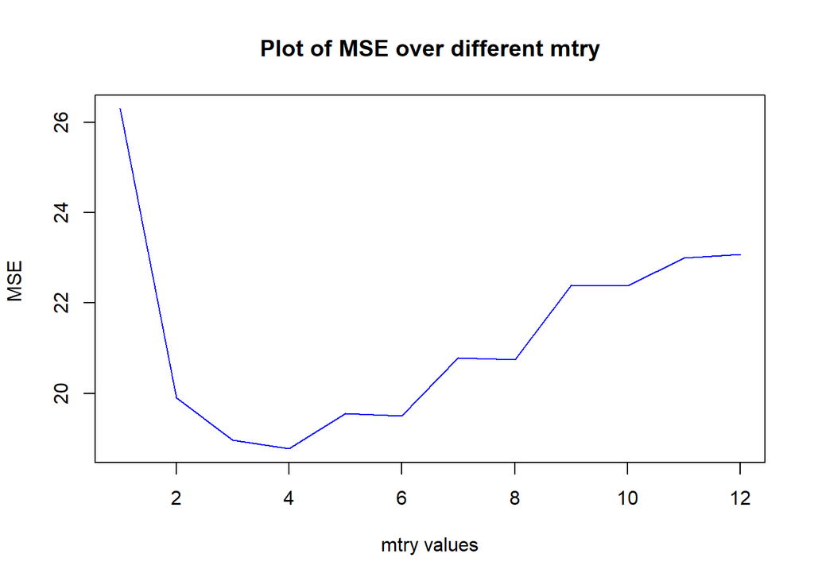

```r
plot(MSE.list, type = "l", col = "blue", xlab = "mtry values", ylab = "MSE ", main = "Plot of MSE over different mtry")
```

Testing out using a different number of trees

```r
bag.boston <- randomForest(medv~., data=Boston, subset=train, mtry = 12, ntree = 25)
yhat.bag <- predict(bag.boston, newdata=Boston[-train,])
mean((yhat.bag-boston.test)^2)
```

```
## [1] 24.50882
```

Creating a for loop to go from 10 to 1000 trees in the random forest counting by 10’s. The number of trees are saved in one vector and the MSE into another.

```r
treeNum <- c()
MSE.list <-c()
for (i in seq(10, 1000, by = 10)) {
  bag.boston <- randomForest(medv~., data=Boston, subset=train, mtry = 12, ntree = i)
  yhat.bag <- predict(bag.boston, newdata=Boston[-train,])
  MSE <- mean((yhat.bag-boston.test)^2)
  treeNum <- c(treeNum, i)
  MSE.list <- c(MSE.list, MSE)

}
```

Graphing the MSE over different numbers of trees used.

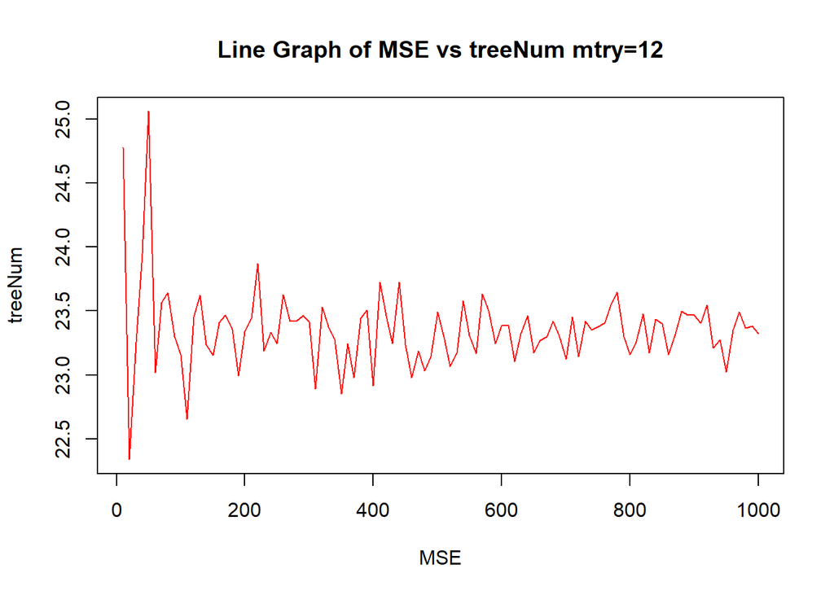

```r
plot(treeNum, MSE.list,  type = "l", col = "red", xlab = "MSE", ylab = "treeNum", main = "Line Graph of MSE vs treeNum mtry=12")
```

```r
treeNum <- c()
MSE.list <-c()
for (i in seq(10, 1000, by = 10)) {
  bag.boston <- randomForest(medv~., data=Boston, subset=train, mtry = 3, ntree = i)
  yhat.bag <- predict(bag.boston, newdata=Boston[-train,])
  MSE <- mean((yhat.bag-boston.test)^2)
  treeNum <- c(treeNum, i)
  MSE.list <- c(MSE.list, MSE)

}
```

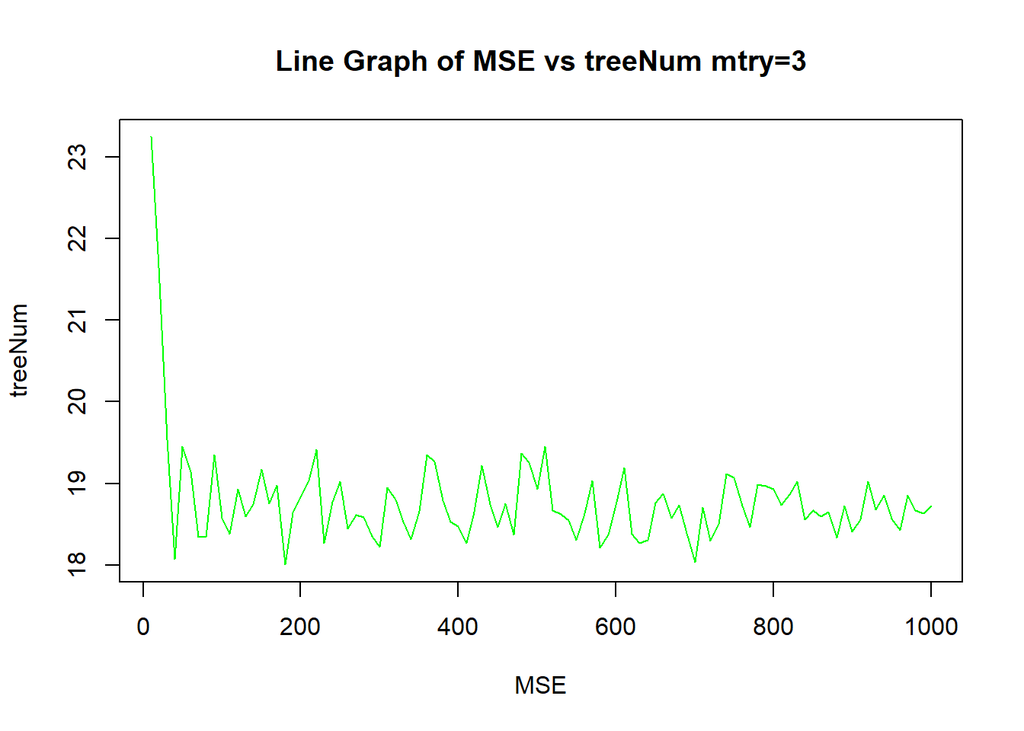

```r
plot(treeNum, MSE.list,  type = "l", col = "green", xlab = "MSE", ylab = "treeNum", main = "Line Graph of MSE vs treeNum mtry=3")
```